# 628hw5

Name: Amber Wang, Group member:Yaoqi Li,Zeying Lang,Jiasheng Chen

3/16/2022

```r
#2a
setwd("~/Downloads")
df1 <- read.csv("toenail-data.csv")
#2b
#for group treatment = 1
miss1=c()
miss0=c()
df_treat = df1[(df1$Treatment==1),]
df_control = df1[(df1$Treatment==0),]
for (i in 1:7){
    miss1[i] = 1-nrow(df_treat[(df_treat$Visit==i),])/length(unique(df_treat$ID))
}
for (i in 1:7){
    miss0[i] = 1-nrow(df_control[(df_control$Visit==i),])/length(unique(df_control$ID))
}

miss = cbind(miss1,miss0)
colnames(miss) = c('treatment_miss','control_miss')
rownames(miss) = c('0week','4week','8week','12week','24week','36week','48week')
miss
```

```
##        treatment_miss control_miss
## 0week     0.000000000   0.00000000
## 4week     0.006756757   0.03424658
## 8week     0.020270270   0.05479452
## 12week    0.054054054   0.09589041
## 24week    0.101351351   0.10958904
## 36week    0.141891892   0.19863014
## 48week    0.114864865   0.08904110
```

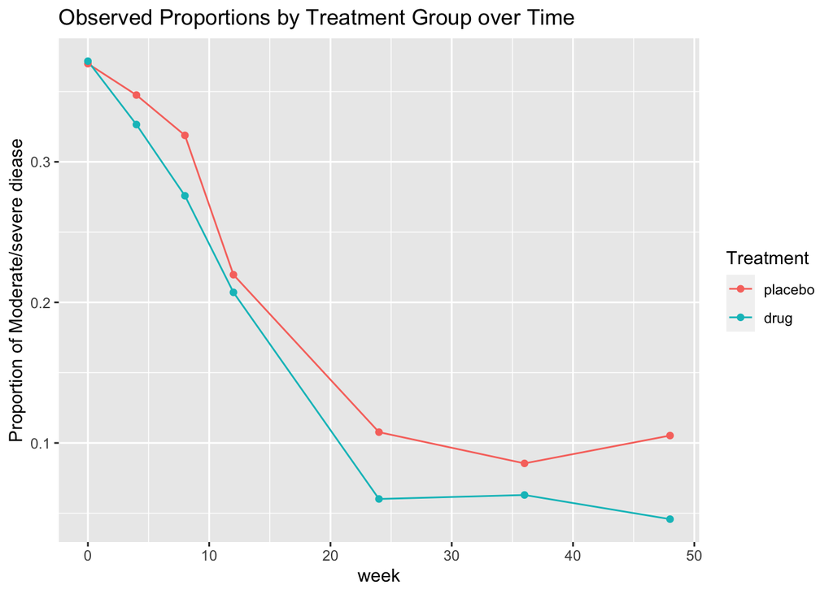

```r
#2c
#Get proportions of Y=1 by treatment group at each time point
df1$Week=as.integer(as.character(factor(df1$Visit,level=c(1:7),labels=c(0,4,8,12,24,36,48))))
df_obs = aggregate(df1$Y, list(df1$Treatment, df1$Week), mean, na.rm=T)
names(df_obs) = c("tx","week","p")
#Calculate odds and log-odds
df_obs$odds = df_obs$p/(1-df_obs$p)
df_obs$logit = log(df_obs$odds)
#change treatment to two factor
df_obs$tx = factor(df_obs$tx, levels = c(0,1),
                         labels = c('placebo','drug'))
library(ggplot2)
p1 = ggplot(df_obs, aes(x=week,y=p,group=tx))
p1 + geom_line(aes(color=tx)) + geom_point(aes(color=tx)) +
  labs(title="Observed Proportions by Treatment Group over Time",
color="Treatment", y="Proportion of Moderate/severe diease")
```

observed probability of moderate/severe onycholysis over weeks of follow up, with the increase of the week the probability will decrease as well. the treatment group will be slightly less than the placebo group.

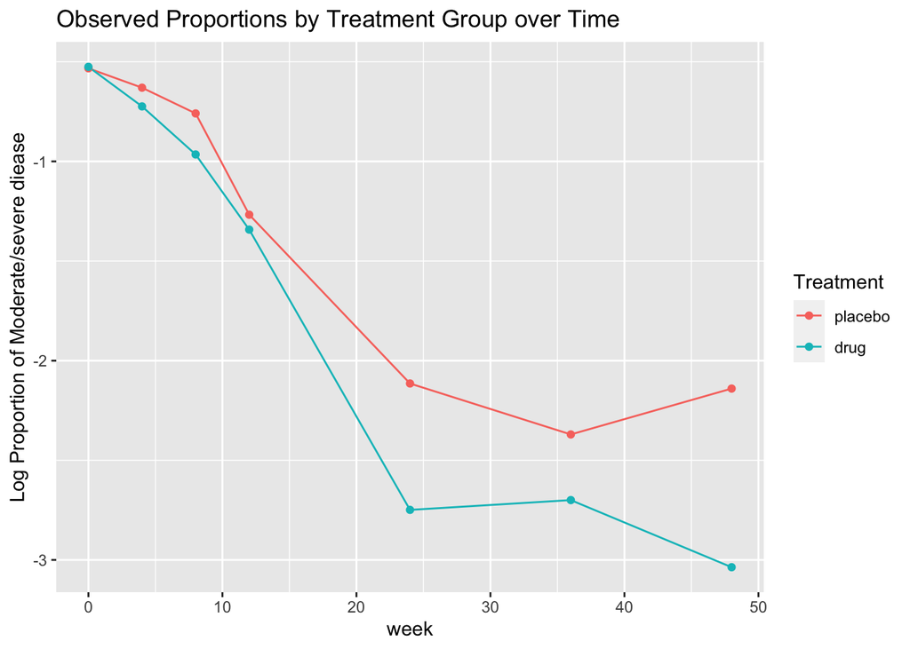

```r
#2d
p2 = ggplot(df_obs, aes(x=week,y=logit,group=tx))
p2 + geom_line(aes(color=tx)) + geom_point(aes(color=tx)) +
  labs(title="Observed Proportions by Treatment Group over Time",
color="Treatment", y="Log Proportion of Moderate/severe diease")
```

observed probability of log moderate/severe onycholysis over weeks of follow up, with the increase of the week the treatment group probability will decrease as well. But the placebo group will increase after week 35. the treatment group will be slightly less than the placebo group.

## 3a

# Equation:

Logit(E(Yij|bi)) = beta1 + beta2*treatmenti +beta3* weekij + beta4*treatment*weekij +bij

## 3b

# Assumptions:

1. Random effects come from a normal distribution bi~N(0,sigma^2)

2.The chosen link function is appropriate.

3.estimation of variance should be proper.

## 3c

# Link function:

g(ui) = log(ui/(1-ui))=logit(ui) so the function is logit.

## 3d

# Liknear predictor:

ni = beta1+beta2*treatment+ beta3* weekij + beta4*treatment*weekij

```r
#3e
library(lme4)
df1$Treatweek <- df1$Treatment * df1$Week
m1 = glmer(Y ~ Week +Treatment+ Treatweek + (1|ID), data=df1,
family=binomial, nAGQ=20, na.action=na.omit) #nAGQ=20: 20 Adaptive Gaussian Quadratu
summary(m1)
```

```
## Generalized linear mixed model fit by maximum likelihood (Adaptive
##   Gauss-Hermite Quadrature, nAGQ = 20) [glmerMod]
##  Family: binomial  ( logit )
## Formula: Y ~ Week + Treatment + Treatweek + (1 | ID)
##    Data: df1
##
##      AIC      BIC   logLik deviance df.resid
##   1257.8   1285.5   -623.9   1247.8     1903
##
## Scaled residuals:
##    Min     1Q Median     3Q    Max
## -2.949 -0.190 -0.088 -0.007 38.170
##
## Random effects:
##  Groups Name        Variance Std.Dev.
##  ID     (Intercept) 16.11    4.014
## Number of obs: 1908, groups:  ID, 294
##
## Fixed effects:
##             Estimate Std. Error z value Pr(>|z|)
## (Intercept) -1.63069    0.43458  -3.752 0.000175 ***
## Week        -0.10104    0.01148  -8.799  < 2e-16 ***
## Treatment   -0.11459    0.58526  -0.196 0.844779
## Treatweek   -0.04032    0.01796  -2.245 0.024785 *
## ---
## Signif. codes:  0 '***' 0.001 '**' 0.01 '*' 0.05 '.' 0.1 ' ' 1
##
## Correlation of Fixed Effects:
##           (Intr) Week   Trtmnt
## Week      -0.173
## Treatment -0.653  0.212
## Treatweek  0.201 -0.555 -0.299
```

```r
m2 = glmer(Y ~ Week + (1|ID), data=df1,
family=binomial, nAGQ=20, na.action=na.omit) #nAGQ=20: 20 Adaptive Gaussian Quadratu
summary(m2)
```

```
## Generalized linear mixed model fit by maximum likelihood (Adaptive
##   Gauss-Hermite Quadrature, nAGQ = 20) [glmerMod]
##  Family: binomial  ( logit )
## Formula: Y ~ Week + (1 | ID)
##    Data: df1
##
##      AIC      BIC   logLik deviance df.resid
##   1259.9   1276.5   -626.9   1253.9     1905
##
## Scaled residuals:
##     Min      1Q  Median      3Q     Max
## -3.3047 -0.1800 -0.0995 -0.0118 23.3468
##
## Random effects:
##  Groups Name        Variance Std.Dev.
##  ID     (Intercept) 16.1     4.012
## Number of obs: 1908, groups:  ID, 294
##
## Fixed effects:
##              Estimate Std. Error z value Pr(>|z|)
## (Intercept) -1.699737   0.329156  -5.164 2.42e-07 ***
## Week        -0.118495   0.009598 -12.345  < 2e-16 ***
## ---
## Signif. codes:  0 '***' 0.001 '**' 0.01 '*' 0.05 '.' 0.1 ' ' 1
##
## Correlation of Fixed Effects:
##      (Intr)
## Week -0.045
```

```r
m3 = glmer(Y ~ Week +Treatment + (1|ID), data=df1,
family=binomial, nAGQ=20, na.action=na.omit) #nAGQ=20: 20 Adaptive Gaussian
summary(m3)
```

```
## Generalized linear mixed model fit by maximum likelihood (Adaptive
##   Gauss-Hermite Quadrature, nAGQ = 20) [glmerMod]
##  Family: binomial  ( logit )
## Formula: Y ~ Week + Treatment + (1 | ID)
##    Data: df1
##
##      AIC      BIC   logLik deviance df.resid
##   1261.0   1283.2   -626.5   1253.0     1904
##
## Scaled residuals:
##     Min      1Q  Median      3Q     Max
## -3.3356 -0.1812 -0.0944 -0.0112 23.6238
##
## Random effects:
##  Groups Name        Variance Std.Dev.
##  ID     (Intercept) 16.05    4.006
## Number of obs: 1908, groups:  ID, 294
##
## Fixed effects:
##              Estimate Std. Error z value Pr(>|z|)
## (Intercept) -1.435864   0.423903  -3.387 0.000706 ***
## Week        -0.118547   0.009602 -12.346  < 2e-16 ***
## Treatment   -0.521715   0.557221  -0.936 0.349128
## ---
## Signif. codes:  0 '***' 0.001 '**' 0.01 '*' 0.05 '.' 0.1 ' ' 1
##
## Correlation of Fixed Effects:
##           (Intr) Week
## Week      -0.063
## Treatment -0.632  0.041
```

```r
m4 = glmer(Y ~ Week + Treatweek + (1|ID), data=df1,
family=binomial, nAGQ=20, na.action=na.omit) #nAGQ=20: 20 Adaptive Gaussian Quadratu
summary(m4)
```

```
## Generalized linear mixed model fit by maximum likelihood (Adaptive
##   Gauss-Hermite Quadrature, nAGQ = 20) [glmerMod]
##  Family: binomial  ( logit )
## Formula: Y ~ Week + Treatweek + (1 | ID)
##    Data: df1
##
##      AIC      BIC   logLik deviance df.resid
##   1255.8   1278.0   -623.9   1247.8     1904
##
## Scaled residuals:
##    Min     1Q Median     3Q    Max
## -2.934 -0.191 -0.089 -0.007 38.570
##
## Random effects:
##  Groups Name        Variance Std.Dev.
##  ID     (Intercept) 16.1     4.012
## Number of obs: 1908, groups:  ID, 294
##
## Fixed effects:
##             Estimate Std. Error z value Pr(>|z|)
## (Intercept) -1.68676    0.32916  -5.124 2.99e-07 ***
## Week        -0.10057    0.01121  -8.969  < 2e-16 ***
## Treatweek   -0.04138    0.01714  -2.414   0.0158 *
## ---
## Signif. codes:  0 '***' 0.001 '**' 0.01 '*' 0.05 '.' 0.1 ' ' 1
##
## Correlation of Fixed Effects:
##           (Intr) Week
## Week      -0.044
## Treatweek  0.003 -0.527
```

```r
anova(m1,m2)
```

```
## Data: df1
## Models:
## m2: Y ~ Week + (1 | ID)
## m1: Y ~ Week + Treatment + Treatweek + (1 | ID)
##    npar    AIC    BIC  logLik deviance  Chisq Df Pr(>Chisq)
## m2    3 1259.9 1276.5 -626.94   1253.9
## m1    5 1257.8 1285.5 -623.89   1247.8 6.1122  2    0.04707 *
## ---
## Signif. codes:  0 '***' 0.001 '**' 0.01 '*' 0.05 '.' 0.1 ' ' 1
```

```r
anova(m1,m3)
```

```
## Data: df1
## Models:
## m3: Y ~ Week + Treatment + (1 | ID)
## m1: Y ~ Week + Treatment + Treatweek + (1 | ID)
##    npar    AIC    BIC  logLik deviance  Chisq Df Pr(>Chisq)
## m3    4 1261.0 1283.2 -626.50   1253.0
## m1    5 1257.8 1285.5 -623.89   1247.8 5.2314  1    0.02218 *
## ---
## Signif. codes:  0 '***' 0.001 '**' 0.01 '*' 0.05 '.' 0.1 ' ' 1
```

```r
anova(m4,m1)
```

```
## Data: df1
## Models:
## m4: Y ~ Week + Treatweek + (1 | ID)
## m1: Y ~ Week + Treatment + Treatweek + (1 | ID)
##    npar    AIC    BIC  logLik deviance  Chisq Df Pr(>Chisq)
## m4    4 1255.8 1278.0 -623.90   1247.8
## m1    5 1257.8 1285.5 -623.89   1247.8 0.0384  1     0.8447
```

##3e ii

(Intercept) -1.63069 , so estimate for the intercept of this model: uij = exp(-1.63069)/(1+exp(-1.63069))

##3e iii since in the model with week and interaction, we done the summary above, The intercept is -1.68676 ,Week -0.10057, Treatweek -0.04138 so Logit(E(Yij|bi)) = beta1 + beta2*treatmenti + beta4*treatment*weekij +bij

the beta2 means each unit increase in week changes of log-odds will change by -0.10057 for unique individual with response ‘positively’ equal to b1i.

the beta3 means each unit increase in weektreatment changes of log-odds will change by -0.04138 for unique individual with response ‘positively’ equal to b1i.

```r
#3e iv.
df1$m1_pred <- predict(m1, newdata=df1, type="response")
df1$m1_pred2 <- predict(m1, newdata=df1, type="response", ReForm=NA)
t_pred <- df1[,c('m1_pred2','Treatment','Week')]
m1_pred <- unique(t_pred)
names(m1_pred) <- c("pred","t","week")
m1_pred$odds <- m1_pred$pred/(1-m1_pred$pred)
m1_pred$logit <- log(m1_pred$odds)
m1_pred <- m1_pred[order(m1_pred$week,m1_pred$t),]
print(m1_pred)
```

```
##            pred t week         odds     logit
## 8  0.1637352107 0    0 0.1957935009 -1.630695
## 1  0.1486434828 1    0 0.1745960473 -1.745280
## 9  0.1155933086 0    4 0.1307015310 -2.034839
## 2  0.0902407547 1    4 0.0991919073 -2.310699
## 10 0.0802479323 0    8 0.0872495264 -2.438983
## 3  0.0533468708 1    8 0.0563531341 -2.876117
## 11 0.0550376625 0   12 0.0582432339 -2.843127
## 4  0.0310222791 1   12 0.0320154720 -3.441536
## 12 0.0170307056 0   24 0.0173257758 -4.055560
## 5  0.0058363762 1   24 0.0058706395 -5.137792
## 13 0.0051275195 0   36 0.0051539464 -5.267993
## 6  0.0010753347 1   36 0.0010764923 -6.834047
## 20 0.0015308117 0   48 0.0015331587 -6.480425
## 7  0.0001973562 1   48 0.0001973951 -8.530303
```

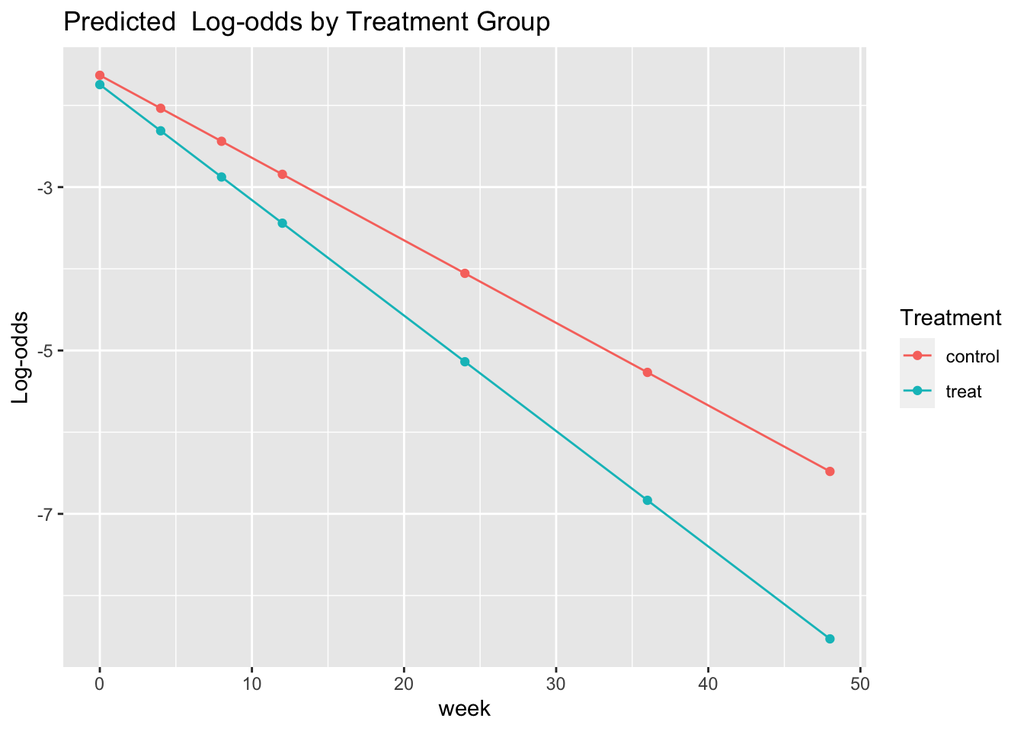

```r
m1_pred$ctx <- factor(m1_pred$t, levels=c(0,1), labels=c("control","treat"))
#Plot average predicted subject-specific log-odds for a ’typical’ subject by treatment gro
pi <- ggplot(m1_pred, aes(x=week,y=logit,group=ctx))
pi + geom_line(aes(color=ctx)) + geom_point(aes(color=ctx)) +
labs(title="Predicted  Log-odds by Treatment Group", color="Treatment", y="Log-odds")
```

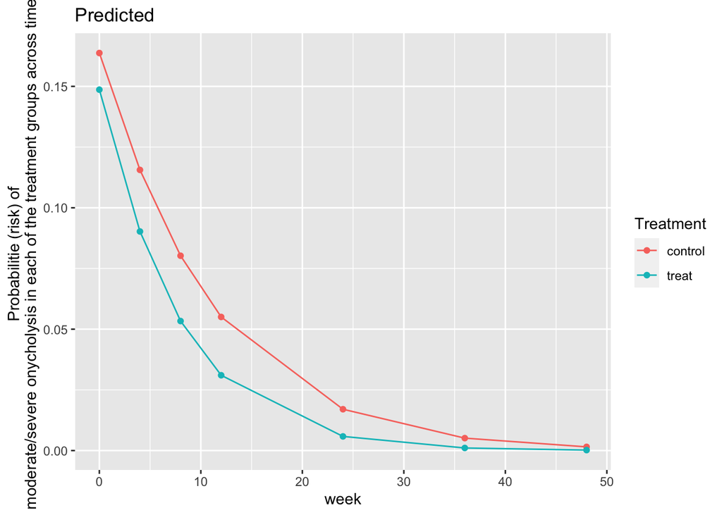

```r
#v
pv <- ggplot(m1_pred, aes(x=week,y=pred,group=ctx))
pv + geom_line(aes(color=ctx)) + geom_point(aes(color=ctx)) +
labs(title="Predicted ", color="Treatment", y="Probabilitie (risk) of
moderate/severe onycholysis in each of the treatment groups across time ")
```

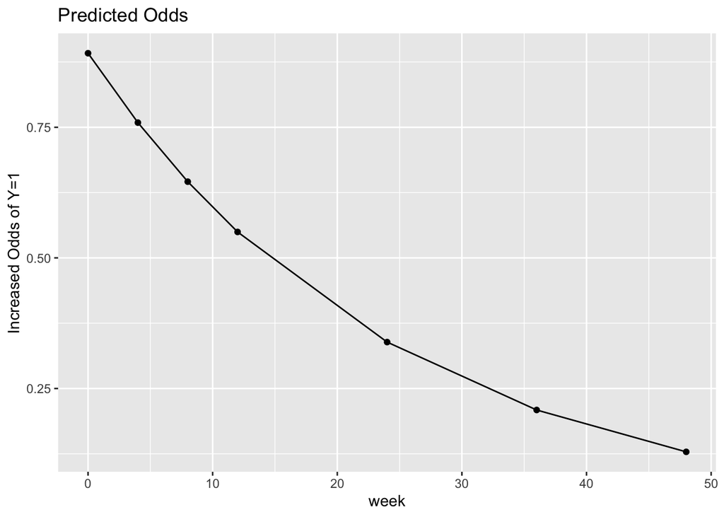

```r
#vi
increase =c()
increase[1] = exp(m1_pred$logit[2]-m1_pred$logit[1])
increase[2] = exp(m1_pred$logit[4]-m1_pred$logit[3])
increase[3] = exp(m1_pred$logit[6]-m1_pred$logit[5])
increase[4] = exp(m1_pred$logit[8]-m1_pred$logit[7])
increase[5] = exp(m1_pred$logit[10]-m1_pred$logit[9])
increase[6] = exp(m1_pred$logit[12]-m1_pred$logit[11])
increase[7] = exp(m1_pred$logit[14]-m1_pred$logit[13])


week <- c(0,4,8,12,24,36,48)
new <- as.data.frame(cbind(week,increase))
pvi <- ggplot(new, aes(x=week,y=increase))
pvi + geom_line() + geom_point()+labs(title="Predicted Odds" ,color="Treatment", y="Increased Odds of Y=1")
```

Estimate subject-specific ratios of increased odds of moderate/severe onycholysis across time (weeks 0, 4,8,12,24,36, 48) in subjects randomized to Terbinafine relative to the subjects randomized to Itraconazole. The week increase, the increased odds decreases.

##3 evii What missing data mechanism assumption for the outcome was used in your GLMM to obtain parameter estimates? What do we need to assume about the joint distribution of the outcomes and the model for the mean response to have unbiased parameter estimates?

we need to assume the missing data are random. and the residuals are normal distribution.